# Funciones de R

Eduardo Alanis

2025-05-21

## Explicación de algunas funciones en R

Las indicaciones iniciales son las siguientes: **Haz un conteo del número de beneficiarias por localidad y una suma de monto de inversión.**

La base de datos que vamos a usar fue convertida de un PDF a un archivo de Excel. Por eso, puede haber algunos problemas, como columnas que se juntaron, espacios extras o que las columnas no se detectaron bien.

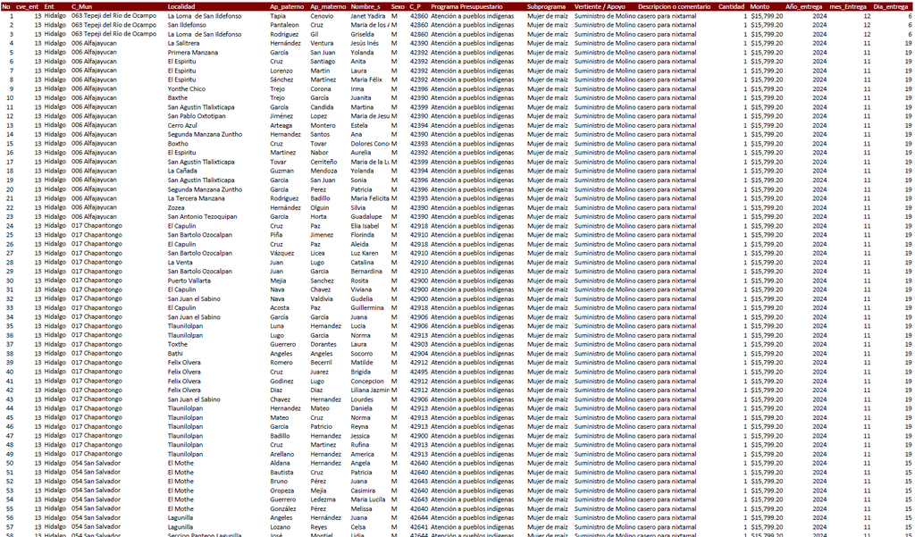

Lo primero que vamos hacer es cargar la base de datos:

```r
datos = readxl::read_excel("C:/Users/SIGEH/Desktop/Lalo/Gob/Documentacion Codigos/Summarize/Datos/24_MM_PUB_4t.xlsx")
```

Primero observamos como esta la base de datos:

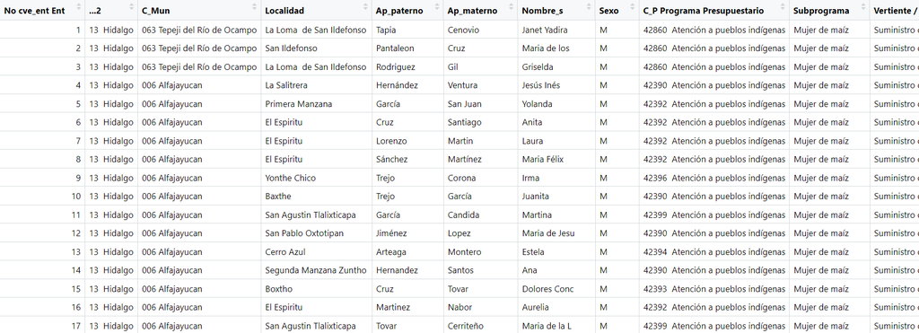

Vamos a renombrar las dos primeras columnas

```r
colnames(datos)[1:2] = c("No", "cve_ent")
```

En la columna `cve_ent`, los datos vienen así: `13 Hidalgo`. Vamos a separarlos en dos partes: `13` como una columna y `Hidalgo` como otra.

Entonces vamos hacerlo de la siguiente forma:

```r
datos = datos |>
  dplyr::mutate(cve_ent = gsub("Hidalgo", "", cve_ent),
                cve_ent = stringr::str_trim(cve_ent))
```

La función `gsub` busca la palabra `"Hidalgo"` y la remplaza por `""`, en otras palabras la elimina por completo, sin dejar ningún espacio. Después usamos la función `str_trim` de la librería `stringr` para quitar los espacios que estén al principio y al final del texto.

Ahora vamos a crear una nueva columna con el nombre de `ent` el cual indicaremos en cada fila tenga el valor de `Hidalgo`.

```r
datos = datos |>
  dplyr::mutate(ent = "Hidalgo")
```

Realizaremos algo parecido pero con la columna de `C_Mun`, dado que los datos vienen de la forma `063 Tepeji del Río de Ocampo`.

```r
datos = datos |>
  dplyr::mutate(C_Mun = substring(C_Mun, first = 1, last = 3)) |>
  dplyr::rename(cve_mun = C_Mun)

municipios = sf::read_sf("C:/Users/SIGEH/Desktop/Lalo/Gob/Importantes_documentos_usar/Municipios/municipiosjair.shp")

municipios = municipios |> dplyr::select(CVE_MUN, NOM_MUN) |> sf::st_drop_geometry()
datos = merge(x = datos, y = municipios, by.x = "cve_mun", by.y = "CVE_MUN", all.x = T)
datos = datos |> dplyr::select(No, cve_ent, ent, cve_mun, NOM_MUN, Localidad:entrega) |>
  dplyr::arrange(No) |>
  dplyr::rename(nom_mun = NOM_MUN)
```

Se aplicó la función `substring` a la columna `C_Mun` para extraer los primeros $3$ caracteres. Luego, esa nueva columna se renombró como `cve_mun`.

Tomamos los nombres de los municipios de otra base de datos que sabemos que todos se encuentran escritos de forma correcta. Esa base viene en formato `SHP` (incluye geometría), así que:

1. Abrimos el archivo con la librería `sf`.
2. Con `dplyr` usamos `select()` para quedarnos solo con las columnas que nos interesan.
3. Aplicamos `st_drop_geometry()` para quitar la parte de geometría.

Ademas vamos a usar la función `merge` para unir dos bases de datos. Donde en este caso vamos agregar una solo nueva columna a datos.

- **x y y:** aquí pones los nombres de las dos bases de datos(`data.frame`) que quieres juntar.
- **by.x y by.y:** indicas las columnas de cada `data.frame` que sirven como clave para emparejar filas (los valores que tienen en común).
- **all.x = TRUE:** se asegura de que el `data.frame x` conserve todas sus filas, aunque no haya coincidencias con el `data.frame y`.

Después de hacer el `merge`, se realizo lo siguiente:

- **Reordenar columnas:** Usamos `select()` para poner las columnas en el orden que queremos.
- **Ordenar filas:** Con arrange(`No`) hacemos que la columna `No` pase de estar en un orden desordenado (6, 7, 1, 2, 3…) a un orden creciente (1, 2, 3,…).
- **Renombrar columnas:** Finalmente, cambiamos el nombre de la columna que se añadio al hacer el `merge()`.

Vamos a realizar algo parecido con la columna de `C_P Programa Presupuestario` ya que se juntaron estas 2 columnas cuando se realizo la conversion, asi que toca separarla.

```r
datos = datos |> dplyr::mutate(CP =  `C_P       Programa Presupuestario`,
                               CP = substr(x = CP, start = 1, stop = 5))

datos = datos |> dplyr::rename(Programa_Presupuestario = `C_P       Programa Presupuestario`) |>
  dplyr::mutate(Programa_Presupuestario = substr(x = Programa_Presupuestario, start = 6, stop = nchar(Programa_Presupuestario)),
                Programa_Presupuestario = stringr::str_trim(Programa_Presupuestario))
```

Primero creamos una copia de la columna `C_P Programa Presupuestario` y la llamamos `CP` para despues en `CP` usamos `substr` para quedarnos sólo con los primeros 5 caracteres de cada valor. Posteriormente renombramos la columna original `C_P Programa Presupuestario` como `Programa_Presupuestario`, en En `Programa_Presupuestario` tomamos, con `substr`, los caracteres desde el sexto hasta el final de cada cadena y finalmente usamos `str_trim` para quitar los espacios en blanco si existen de la cadena.

Ahora vamos a trabajar con la columna `Cantidad Monto Año`, ya que en ella se combinaron dos columnas por error. Lo que haremos es separarla en dos columnas: una llamada `Cantidad` y otra llamada `Monto`.

```r
datos = datos |> dplyr::rename(Monto = `Cantidad    Monto           Año`) |>
  dplyr::mutate(Cantidad = Monto,
                Cantidad = sub(x = Cantidad, pattern = "\\$.*", replacement = ""),
                Cantidad = stringr::str_trim(Cantidad))


datos = datos |> dplyr::mutate(Monto = sub(x = Monto, pattern = ".*\\$", replacement = ""),
                               Monto = gsub(x = Monto, pattern = ",", replacement = ""),
                               Monto = as.numeric(Monto))
```

Renombramos la columna llamada `Cantidad Monto Año` como `Monto`. Luego, copiamos esa misma columna en una nueva columna llamada `Cantidad`, después usaremos la función `sub` para quedarnos solo con el texto que está antes del símbolo `$`. Esta función reemplaza todo lo que está después del `$` por una cadena vacía (`""`), es decir, lo elimina. Por último, aplicamos la función `str_trim` para quitar los espacios en blanco que pueda haber al principio o al final del texto.

De manera similar, con la columna `Monto` vamos a extraer solo lo que está después del símbolo `$` usando la función `sub`. Luego, usamos la función `gsub` para eliminar todas las `comas(,)` que puedan tener los valores y finalmente usamos `as.numeric` para convertir ese caracter en un número.

Ahora vamos a renombrar ciertas columnas y ordenadar la base de datos

```r
datos = datos |> dplyr::rename(Año_entrega = `_entrega     mes_`,
                               Mes_entrega = `Entrega     Dia_`,
                               Dia_entrega = entrega)


datos = datos |> dplyr::select(No:Sexo, CP, Programa_Presupuestario, Subprograma, `Vertiente / Apoyo         Descripcion o comentario`, Cantidad, Monto, Año_entrega, Mes_entrega, Dia_entrega)
```

Usamos la función rename de la librería dplyr para cambiar los nombres de las siguientes columnas:

- `_entrega mes_` → `Año_entrega`
- `Entrega Dia_` → `Mes_entrega`
- `entrega` → `Dia_entrega`

Después, utilizamos la función `select` para ordenar las columnas en la base de datos, solo escribimos los nombres de las columnas que queremos conservar, en el orden en que deseamos que aparezcan.

Finalmente limpiados un poco la columna `Localidad`

```r
datos = datos |> dplyr::mutate(Localidad = stringr::str_trim(Localidad),
                               Localidad = gsub(x = Localidad, pattern = "  ", replacement = " "))
```

Con la función `str_trim` se quita los espacios en blanco si existen de inicio y final de los caracteres, ademas con la `gsub` indicamos que si existen espacios dobles estos sean remplazados unicamente con un espacio.

#### Ahora si lo solicitado

Lo que es necesario es crear un ID correcto, para hacer una agrupacion de manera adecuada

```r
datos = datos |> dplyr::mutate(ID = paste0(cve_ent, cve_mun, "-", tolower(stringi::stri_trans_general(Localidad, "Latin-ASCII"))))
```

La forma de construir el ID fue la siguiente:

- Primero vamos a trabajar con la variable `Localidad`. Usaremos la función `stri_trans_general` de la librería `stringi` para quitar los acentos, y luego aplicaremos `tolower` para convertir todo el texto a minúsculas. Esto es útil porque muchas veces las bases de datos se escriben a mano, y pueden tener muchos errores de mayúsculas, minúsculas o acentos dado que los llenas distintas personas. También hay que recordar que antes ya limpiamos los espacios del texto de esta columna.
- Después, creamos una nueva columna llamada `ID` uniendo (concatenando) las variables `cve_ent`, `cve_mun`, un guion (-) y la variable `localidad`.

Vamos agrupar los datos apartir del ID, ademas de solicitar el monto y conteo de los elementos que fueron agrupados

```r
interes = datos |>
  dplyr::group_by(ID) |>
  dplyr::summarise(conteo = dplyr::n(), Monto = sum(Monto))
```

Lo que hace el codigo es lo siguiente:

1. **Agrupar por ID**
   - Usamos group_by(ID) para juntar todas las filas que tienen el mismo valor en la columna ID.
2. **Resumir los datos** Con summarise() pedimos dos cosas para cada grupo:
   - conteo: cuántas filas hay en ese grupo, usando n().
   - Monto: la suma de la columna Monto dentro de ese grupo, usando sum(Monto).

Al final, interes será una tabla donde cada fila es un ID distinto, junto con el número de veces que aparece (conteo) y la suma de los montos asociados.

```r
interes
```

```
## # A tibble: 370 × 3
##    ID                             conteo  Monto
##    <chr>                           <int>  <dbl>
##  1 13006-baxthe                        1 15799.
##  2 13006-boxtho                        1 15799.
##  3 13006-cerro azul                    1 15799.
##  4 13006-el espiritu                   4 63197.
##  5 13006-la canada                     1 15799.
##  6 13006-la salitrera                  1 15799.
##  7 13006-la tercera manzana            1 15799.
##  8 13006-primera manzana               1 15799.
##  9 13006-san agustin tlalixticapa      3 47398.
## 10 13006-san antonio tezoquipan        1 15799.
## # ℹ 360 more rows
```

#### Notas:

1. **Diferencia entre sub() y gsub():** Tenemos que `sub()` como `gsub()` se utilizan para reemplazar texto mediante expresiones regulares, pero:
   - **sub():** Reemplaza solo la primera aparición del patrón dentro de cada cadena.
   - **gsub():** Reemplaza todas las apariciones del patrón dentro de cada cadena.
2. **Documentacion de codigos:** Donde seleccionas para crear un nuevo archivo, existe un apartado llamado `R Markdown` el cual te permite crear archivos como el que estas leyendo.
3. **Proyectos:** Si vas a trabajar con múltiples archivos de datos, scripts, gráficos, etc. Un `proyecto` te permite mantener todo bien organizado.